# UUK and UCU proposed agreement

Richard Wilkinson

12/03/2018

#### Update: 14 March 2108

I did the analysis below in a rush after the proposed agreement was published, to highlight the pernicious effect of the inflation cap. It *wasn’t* intended as a careful analysis. Several people have emailed me with suggested changes. I’m not an expert (or even knowledgeable) in this area, so rather than attempt to incorporate all these suggestions, I’ve listed them in the update section below, and linked to more complete analyses. I’ve left the original post unaltered below so that it is still available.

#### Original post: 12 March 2018

We have just been sent the proposed details of the agreement between UUK and UCU. Part of this agreement is that the accrual rate for benefits will change from 1/75 to 1/85 of our average salary, that the cap is lowered to £42,000, and that inflation protection is limited to just 2.5%.

Let’s do some calculations to see what this means. Please note that I’m not a pensions expert, nor am I proficient at finacial calculations. I’ll happily correct this if someone points out errors.

In order to get an upper bound on the defined benefits, let’s assume someone comes into academia on a salary above the £42,000 cap (which isn’t far from possible anyway) and then goes on to have a 40 year career. What would the defined benefit part of their pension be worth when they retire?

Without inflation, this would be

```r
(base <- 42000*40/85)
```

```
## [1] 19764.71
```

per year.

To calculate the effects of inflation, we need some assumptions about what the future inflation rate will be. For the sake of simplicity, let’s assume history repeats itself and use the CPI rate from the past 40 years. I’ve taken the historic CPI values from here. The CPI varied over this time period as follows:

```r
tmp <- read.table('UK_CPI.txt')
data <- data.frame('Year'= c(tmp[,4],tmp[,10]), 'CPI'=c(tmp[,5], tmp[,11]))
data <- data[-64,]
(cpi <- data[1:40,2])
```

```
##  [1]  2.96  2.69  0.64  0.05  1.47  2.53  2.83  4.48  3.29  2.17  3.61
## [12]  2.32  2.33  2.05  1.34  1.36  1.26  1.24  0.79  1.34  1.59  1.78
## [23]  2.48  2.66  1.98  2.51  4.30  7.53  6.96  5.24  3.99  4.15  3.44
## [34]  6.07  4.96  4.61  8.66 11.89 18.07 13.35
```

The earlier values are the most recent past - the later values are the high inflation in the late 70s/early 80s.

If I’ve understood correctly, these CPI rates will all be truncated at 2.5%, meaning our benefits would be (under this hypothetical future) subject to the following rises due to inflation:

```r
(truncated_cpi <- sapply(data[1:40,2],function(x)min(x,2.5)))
```

```
##  [1] 2.50 2.50 0.64 0.05 1.47 2.50 2.50 2.50 2.50 2.17 2.50 2.32 2.33 2.05
## [15] 1.34 1.36 1.26 1.24 0.79 1.34 1.59 1.78 2.48 2.50 1.98 2.50 2.50 2.50
## [29] 2.50 2.50 2.50 2.50 2.50 2.50 2.50 2.50 2.50 2.50 2.50 2.50
```

If we calculate what the defined benefits will be under this (hypothetical) inflationary future, we find that this academic will receive

```r
(actual_pension <- base*prod(truncated_cpi/100+1))
```

```
## [1] 45213.49
```

a year as defined benefit upon retirement.

Sounds great! But remember, this has had inflation protection limited to 2.5% a year. To calculate the real terms value of the pension, we can compare it to the pension our theoretical academic would have received if their benefits were uprated in line with the true inflation rate. This would be

```r
(inflation_adjusted_pension <- base*prod(cpi/100+1))
```

```
## [1] 90077.1
```

per year.

So in real terms (i.e., today’s money), the pension this theoretical academic would receive will only be

```r
(real_terms_pension <- actual_pension/prod(cpi/100+1))
```

```
## [1] 9920.738
```

per year.

So the pensions changes imposed upon us over the last decade (by people who are likely to have already accrued significant benefit under the older more generous scheme) have seen the upper bound for the defined benefits pension change from us receiving 1/2 = 40/80 of our (uncapped) final salary, to 40/75 of our career average (capped at £55,000/year), to just shy of £10,000 per year under the proposed scheme.

Moreover, the language of the agreement make clear this is an interim agreement only for the next three years. I cannot believe that the terms will be improved upon in three years time.

## Update: 14 March 2108

I did the analysis above very quickly after the proposed agreement was published. It was intended just to highlight the potentially pernicious effect of the 2.5% cap on inflation protection. Several people have emailed me with suggestions for changes. These include

- ignoring that since the 1990s the UK has had an [inflation target](http://www.bbc.co.uk/news/31559074) of 2%, which has largely been successful. We’ve not seen the very high levels of inflation we saw in the 70s and 80s since then, but we have had periods of inflation greater than 2.5%.

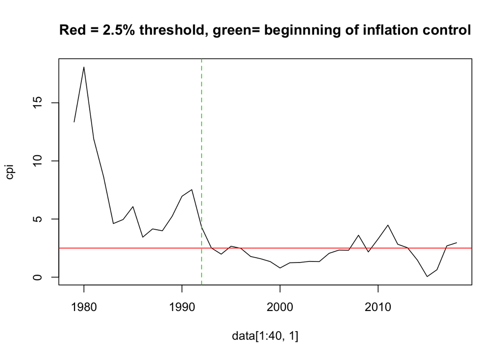

- I didn’t model the effect of the salary cap (the £42,000) increasing at a below inflation rate
- I may have misunderstood the detail of how the benefits are inflation proofed. It may be that the correct calculation is that our pension would have shrunk by a factor of

```r
sum(cumprod(truncated_cpi/100+1))/sum(cumprod(cpi/100+1))
```

```
## [1] 0.8386397
```

compared to real terms, i.e., 84% rather than the 50% reduction I calculated. This would be the case if we assume that the benefits we accrue each year are inflation-protected separately. So the benefit I accrue in year 1 is subject to the entire 40 year history of capped inflation increases, but the pension I accrue in the final year only suffers from one year of capped inflation increases.

As I said in the original post, I don’t have any expertise in this area. I did think about updating the calculation, but I find that the detail in the proposal isn’t clear enough (or easy enough to access) for me to be certain what the correct way of thinking about this is. That in itself is worrying. Neither USS, UUK, or UCU have, as far as I’m aware, spelt out the detail in a way that is clear. But what is clear is that this inflation cap shifts potentially significant risk onto the individual, and away from the employer.

Given that the deal has (thankfully!) been rejected, rather than attempt to get to the bottom of the details myself, I’m going to simply point at much more complete attempts by [Ian Sudbury](https://iansudbery.github.io/uss-pensions-proposal/PensionsCap2.html) and [Henry Lahr](http://www.henrylahr.com/?p=502) to do this more carefully.